# Case Study 1 - Budweiser EDA

# 9. Knock their socks off! Find one other useful inference from the data that you feel Budweiser may be able to find value in.

Given the data an interesting area of investigation could involve analyzing beer styles’ popularity and market trends, such as the relationship between ABV (Alcohol By Volume), IBU (International Bitterness Units), and the popularity or prevalence of beer styles. For this analysis, we can hypothesize that beers with specific ABV and IBU ranges tend to be more popular or prevalent, indicating consumer preference trends.

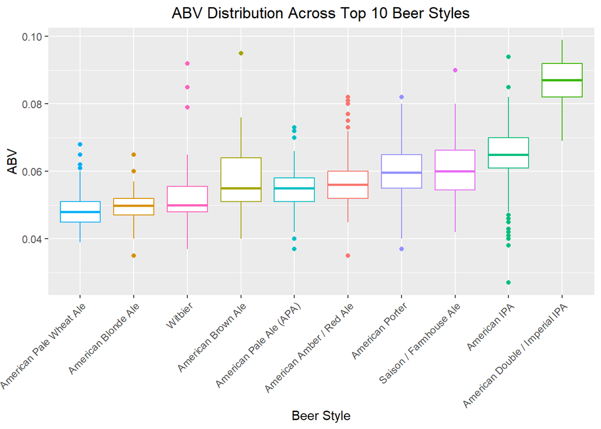

```r
#Exploring the distribution of ABV and IBU across different beer styles


# ABV distribution across top 10 beer styles
# Filter for only the top 10 most common beer styles
top_styles <- beers_breweries %>%
  count(Style) %>%
  top_n(10, n) %>%
  pull(Style)

filtered_data <- beers_breweries %>%
  filter(Style %in% top_styles)
library(ggplot2)
# Creating the boxplot with the filtered data
ggplot(filtered_data, aes(x = reorder(Style, ABV, FUN = median), y = ABV)) +
  geom_boxplot(aes(color = Style)) +
  theme(axis.text.x = element_text(angle = 45, hjust = 1),
        legend.position = "none") +
  labs(title = "ABV Distribution Across Top 10 Beer Styles", x = "Beer Style", y = "ABV") +
  theme(plot.title = element_text(hjust = 0.5))  # Center the plot title
```

A quick glance at the plot suggests that there is considerable diversity in ABV across beer styles. Some styles, like American Double/Imperial IPA, have a higher median ABV, reflecting their characteristically stronger profiles. The range of ABV values within styles could reflect diverse consumer preferences, with some consumers preferring lighter beers and others seeking stronger options.

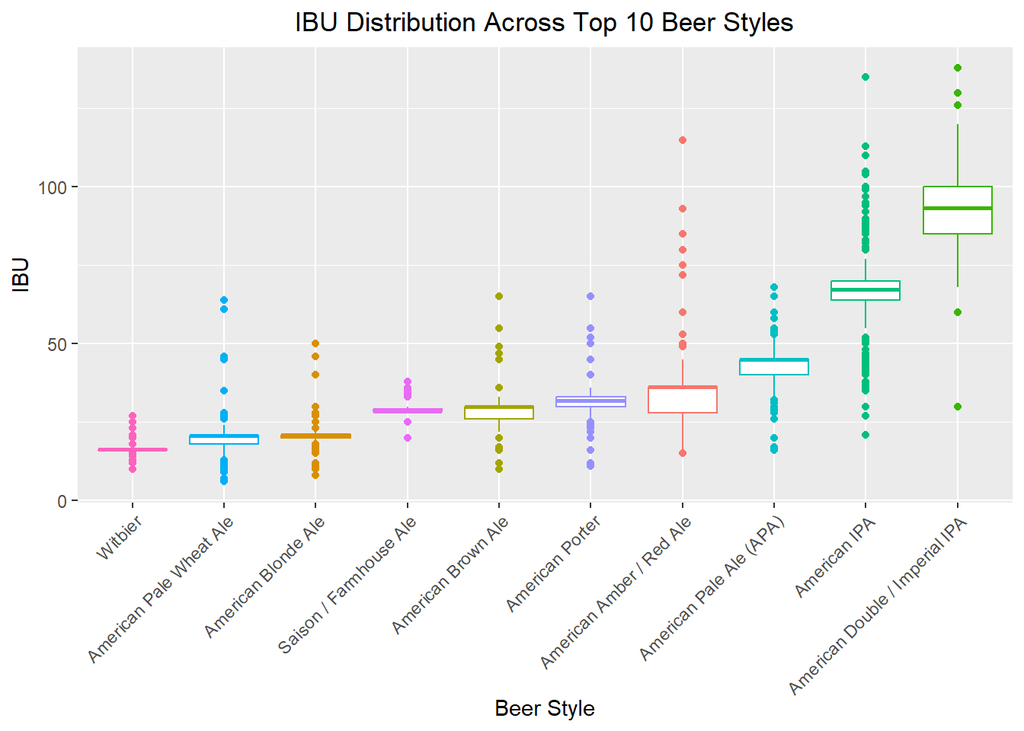

```r
# IBU distribution across beer styles
ggplot(filtered_data, aes(x = reorder(Style, IBU, FUN = median), y = IBU)) +
  geom_boxplot(aes(color = Style)) +
  theme(axis.text.x = element_text(angle = 45, hjust = 1)) +
  theme(plot.title = element_text(hjust = 0.5),
        legend.position = "none") +
  labs(title = "IBU Distribution Across Top 10 Beer Styles", x = "Beer Style", y = "IBU")
```

Beer styles with higher IBU are often perceived as more bitter, and this plot shows which styles tend to have higher bitterness levels. This information could help Budweiser decide on product development strategies, such as creating beers that fit popular or niche bitterness profiles. Understanding the range and common values of IBU for popular styles can also inform quality control and consistency efforts in beer production.

# Conclusion

In this exploratory data analysis (EDA) of the Beers and Breweries dataset, we gained valuable insights into the characteristics of different types of beers and the distribution of breweries across various states. Here are some key findings from our analysis:

• Breweries per State.

• Dealing w/ Missing Values in the dataset.

• Plotting the Median ABVs & IBUs by State.

• Finding the Maximum ABV & IBU and Where They’re Located.

• A Breakdown of the ABV Variable.

• Analyzing the Relationship (if any) between ABV and IBU.

• kNN Investigation.

• Exploring the Distribution of ABV and IBU Across Different Beer Styles.

Overall, this EDA provides a comprehensive overview of the Beers and Breweries dataset, laying the foundation for further analysis and exploration. The insights gained from this analysis can inform various stakeholders in the brewing industry, most specifically our “client” Budweiser, as well as other brewers, distributors and enthusiasts, helping them make informed decisions while better understanding market trends.